# The Development of a Naive Bayes and Neural Network Classifier on Gesture Phase Segmentation:

Orginated Dataset: https://archive.ics.uci.edu/ml/datasets/gesture+phase+segmentation

# *I. Importing packages.*

This will contain packages that will be used both for the Naive Bayes Classifier and Neural Network Classifier. Graphs will be constructed with the help from `matplotlib` as well as dervived libraries such as `seaborn`.

```python
import pandas as pd
import numpy as np
import glob

import seaborn as sns
import matplotlib.pyplot as plt

from sklearn.model_selection   import train_test_split, cross_val_score, cross_val_predict, GridSearchCV, RandomizedSearchCV
from sklearn.metrics           import accuracy_score, confusion_matrix, classification_report
from sklearn                   import preprocessing

#Naive Bayes future Tools

from sklearn.naive_bayes       import GaussianNB, MultinomialNB, BernoulliNB
from sklearn.ensemble          import ExtraTreesClassifier

#Neural Network future Tools

# Python ≥3.5 is required
import sys
assert sys.version_info >= (3, 5)

# Scikit-Learn ≥0.20 is required
import sklearn
assert sklearn.__version__ >= "0.20"

# TensorFlow ≥2.0 is required
import tensorflow as tf
assert tf.__version__ >= "2.0"

from tensorflow import keras

# to make this notebook's output stable across runs
np.random.seed(42)

# To plot pretty figures
%matplotlib inline
import matplotlib as mpl
import matplotlib.pyplot as plt
mpl.rc('axes', labelsize=14)
mpl.rc('xtick', labelsize=12)
mpl.rc('ytick', labelsize=12)


# Ignore useless warnings (see SciPy issue #5998)
import warnings
warnings.filterwarnings(action="ignore", message="^internal gelsd")

keras.__version__
```

```
'2.2.4-tf'
```

# *II. Importing dataset.*

The orginal dataset was composed on 14 individual files: 7 raw files and 7 processed files. There was no master dataset so individual files were download. To get the desired dataset with User A and their three comic strips (1,2,3), I had to converge the individual files below.

```python
data1 = pd.read_csv('a1_va3.csv', header=0)
data2 = pd.read_csv('a2_va3.csv', header=0)
data3 = pd.read_csv('a3_va3.csv', header=0)
data = pd.concat([data1, data2, data3])
```

# *III. Cleaning and Checking for missing Values.*

Checking for missing values.

```python
data.isnull().values.any()
```

```
False
```

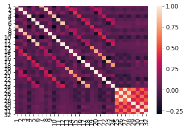

```python
td_corr = data.corr()
sns.heatmap(td_corr, xticklabels=td_corr.columns, yticklabels=td_corr.columns)
```

Selecting independent features needed to happen to get a better classification in further analysis. The selected 12 attributes are shown below as well as a scatterplots between the selected features.

```python
#feature revision
attributes = ['1', '2', '3', '4', '5', '6', '13', '14', '15', '16', '17', '18']
data = data[attributes + ['Phase']]
```

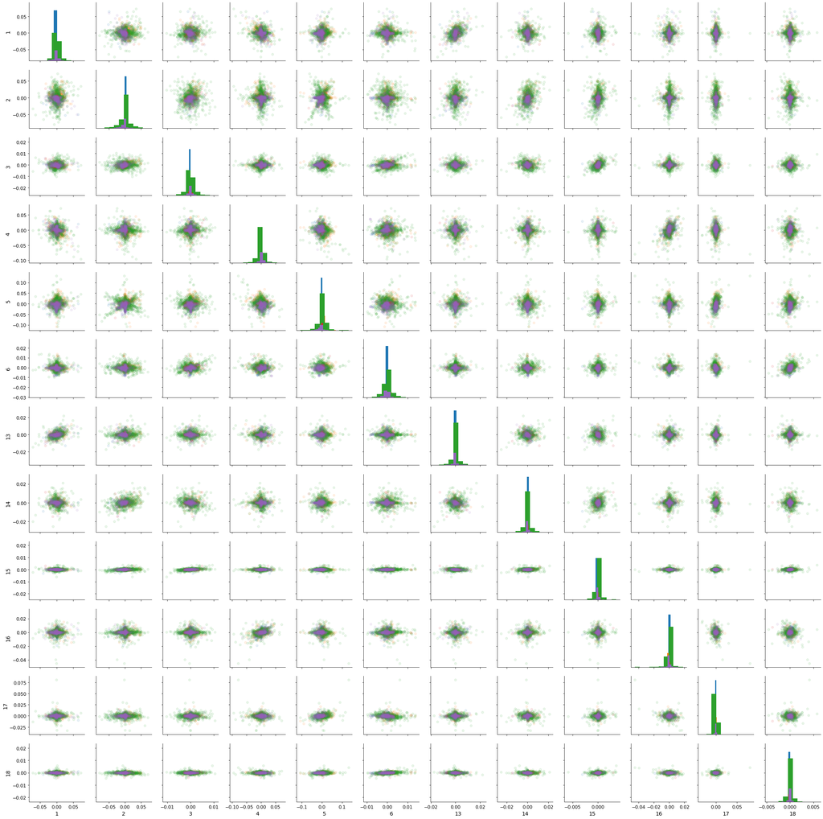

```python
#visualizing by scatter plot
g = sns.PairGrid(data, hue = "Phase")
g.map_diag(plt.hist)
g.map_offdiag(plt.scatter, alpha = 0.1)
```

# *IV. Naive Bayes Classifiers.*

**Let's first take a look at the distribution of gesture classifications.**

```python
#counting the number of each category
data.iloc[:, -1].value_counts()
```

```
D    1841
S    1622
P     642
R     485
H     243
Name: Phase, dtype: int64
```

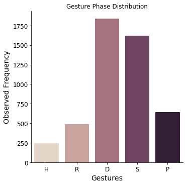

```python
dist = sns.catplot(x="Phase", kind="count", palette="ch:.18", data=data, order=["H","R","D", "S","P"])
# Add labels
plt.title('Gesture Phase Distribution')
plt.xlabel('Gestures')
plt.ylabel('Observed Frequency')
```

*Choosing which Naive Bayes Model works best*

```python
dataset = data.drop('Phase', axis=1).values
X_train, X_test, y_train, y_test = train_test_split(dataset, data["Phase"], test_size=0.33, random_state = 42)
```

```python
BernNB = BernoulliNB(binarize = True)
BernNB.fit(X_train, y_train)
print(BernNB)

bern_y_pred = BernNB.predict(X_test)
BERN_ACC = accuracy_score(y_test, bern_y_pred)
print(BERN_ACC)
```

```
BernoulliNB(alpha=1.0, binarize=True, class_prior=None, fit_prior=True)
0.3799373040752351
```

```python
MultiNB = MultinomialNB()
#MultiNB.fit(X_train, y_train)
#print(MultiNB)

#y_pred = MultiNB.predict(X_test)
#print(accuracy_score(y_test, y_pred))
```

MultinomialNB fails when features have negative values so this Bayesian Classifier cannot be used with this dataset without scaling.

```python
GausNB = GaussianNB()
GausNB.fit(X_train, y_train)
print(GausNB)

gaus_y_pred = GausNB.predict(X_test)
GAUS_ACC = accuracy_score(y_test, gaus_y_pred)
print(GAUS_ACC)
```

```
GaussianNB(priors=None, var_smoothing=1e-09)
0.515987460815047
```

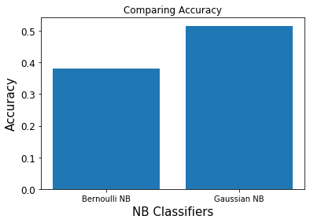

```python
NB_labels = ['Bernoulli NB', "Gaussian NB"]
NB_Accuracies = [BERN_ACC, GAUS_ACC]
def NB_accuracy_bar():
    ind = np.arange(len(NB_labels))
    plt.bar(ind, NB_Accuracies)
    plt.xlabel('NB Classifiers', fontsize = 15)
    plt.ylabel('Accuracy', fontsize = 15)
    plt.xticks(ind, NB_labels, fontsize = 10)
    plt.title('Comparing Accuracy')
    plt.show
NB_accuracy_bar()
```

We can see through the different accuracy scores that the right Naive Bayes Classifier for this dataset would have to be the Gaussian.

# *V. Neural Network Classifier*

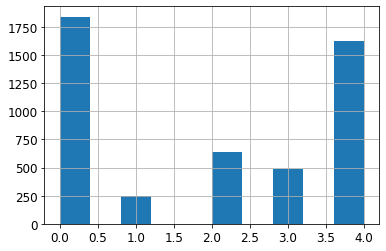

```python
#data[attributes]
#sns.countplot(data['Phase'])

from sklearn import preprocessing
le = preprocessing.LabelEncoder()
le.fit(data['Phase'])
data['Phase2'] = le.transform(data['Phase'])
data['Phase2'].hist()
```

```python
y = keras.utils.to_categorical(data['Phase2'])
y
```

```
array([[1., 0., 0., 0., 0.],
       [1., 0., 0., 0., 0.],
       [1., 0., 0., 0., 0.],
       ...,
       [1., 0., 0., 0., 0.],
       [1., 0., 0., 0., 0.],
       [1., 0., 0., 0., 0.]], dtype=float32)
```

```python
X = data[attributes].values
X
```

```
array([[-5.00942e-03, -9.63710e-04,  5.72770e-04, ...,  6.11390e-04,
         4.53070e-04,  5.90320e-04],
       [ 4.90517e-03,  1.20913e-03, -6.48600e-04, ..., -2.77570e-04,
        -1.78610e-04, -3.44800e-05],
       [-2.39286e-03, -2.15880e-04,  1.36300e-04, ..., -5.51340e-04,
        -6.30570e-04, -1.55830e-04],
       ...,
       [ 7.98000e-05, -6.02300e-05, -1.15190e-04, ..., -5.71000e-06,
        -2.35000e-06,  3.51000e-06],
       [-2.06000e-05, -6.69100e-05, -1.11470e-04, ..., -1.71000e-06,
        -2.92000e-06,  3.34000e-06],
       [-1.04320e-04, -7.90000e-05, -1.05560e-04, ...,  9.30000e-07,
        -8.40000e-07,  3.15000e-06]])
```

## Building a keras model with dense layers:

```
Train on 4833 samples
```

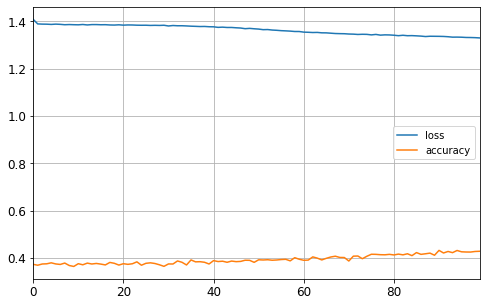

```python
keras.backend.clear_session()
np.random.seed(42)
tf.random.set_seed(42)

model = keras.models.Sequential()

model.add(keras.layers.Dense(100, input_dim=12, activation="sigmoid"))
model.add(keras.layers.Dense(50, activation="sigmoid"))
model.add(keras.layers.Dense(5, activation="softmax"))

model.compile(
    loss='categorical_crossentropy', optimizer= 'rmsprop',
#   optimizer = keras.optimizers.SGD(lr=0.01, nesterov=True),
    metrics=['accuracy'])

history = model.fit(X, y, epochs=100, batch_size = 48)

pd.DataFrame(history.history).plot(figsize=(8, 5))
plt.grid(True)
```

**Hyperparameters: Seeing whether we are overfitting and using validation Data.**

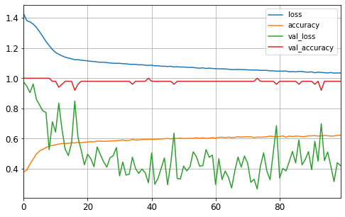

```python
# To plot pretty figures
%matplotlib inline
import matplotlib as mpl
import matplotlib.pyplot as plt
mpl.rc('axes', labelsize=14)
mpl.rc('xtick', labelsize=12)
mpl.rc('ytick', labelsize=12)

y = keras.utils.to_categorical(data['Phase2'])
X = data[attributes].values

X_valid, X_train = X[:50], X[50:]
y_valid, y_train = y[:50], y[50:]

keras.backend.clear_session()
np.random.seed(42)
tf.random.set_seed(42)

model = keras.models.Sequential()

model.add(keras.layers.Dense(100, input_dim=12, activation="relu"))
model.add(keras.layers.Dense(50, activation="relu"))
model.add(keras.layers.Dense(5, activation="softmax"))

model.compile(
    loss='categorical_crossentropy',
    optimizer= 'rmsprop',
#    optimizer = keras.optimizers.RMSprop(lr=0.01, rho=0.9),
    metrics=['accuracy'])

history = model.fit(X_train, y_train,
                    validation_data = (X_valid, y_valid),
                    epochs=100, batch_size = 50, verbose = 0)

pd.DataFrame(history.history).plot(figsize=(8, 5))
plt.grid(True)
```

```python
dat1 = pd.read_csv('a1_va3.csv', header=0)
dat2 = pd.read_csv('a2_va3.csv', header=0)
dat3 = pd.read_csv('a3_va3.csv', header=0)
testing = pd.concat([dat1, dat2, dat3])


testing['Phase2'] = le.transform(testing['Phase'])
X_testing = testing[attributes].values
y_testing = keras.utils.to_categorical(testing['Phase2'])

NN_score, NN_acc = model.evaluate(X_testing, y_testing, verbose=0)
print([NN_score, NN_acc])
```

```
[1.0184361956552668, 0.6327333]
```

```python
model.summary()
```

```
Model: "sequential"
_________________________________________________________________
Layer (type)                 Output Shape              Param #
=================================================================
dense (Dense)                (None, 100)               1300
_________________________________________________________________
dense_1 (Dense)              (None, 50)                5050
_________________________________________________________________
dense_2 (Dense)              (None, 5)                 255
=================================================================
Total params: 6,605
Trainable params: 6,605
Non-trainable params: 0
_________________________________________________________________
```

```
Neural Network: Accuracy: 0.6327333
              precision    recall  f1-score   support

           0      0.875     0.647     0.744      2487
           1      0.000     0.000     0.000         0
           2      0.106     0.731     0.185        93
           3      0.443     0.485     0.463       443
           4      0.718     0.644     0.679      1810

    accuracy                          0.633      4833
   macro avg      0.428     0.502     0.414      4833
weighted avg      0.762     0.633     0.683      4833
```

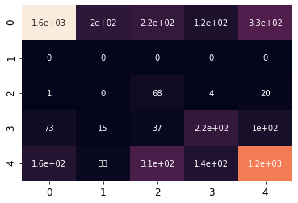

```python
from sklearn.metrics import confusion_matrix
from sklearn import metrics

y_pred = model.predict(X_testing)
y_pred_bool = np.argmax(y_pred, axis=1)
confusion = confusion_matrix(y_pred_bool, data['Phase2'])
ax = sns.heatmap(confusion,annot=True,cbar=False)
# The rest of this code is needed because of a bug in matplotlib 3.1.1
bottom, top = ax.get_ylim()
ax.set_ylim(bottom + 0.5, top - 0.5)
print("Neural Network: Accuracy:", NN_acc)
print(metrics.classification_report(y_pred_bool, data['Phase2'], digits=3))
```